# Data Report - Educational Attainment and Hate Speech Definition/Attitudes

Johanna Mehler

30 January, 2024

# 1 Preprocessing

## 1.1 Load data and select relevant survey items

As a first step, we load the data and print the variable names in order to identify the parts of the questionnaire that are relevant for the study.

```
##   [1] "StartDate"                         "EndDate"
##   [3] "Status"                            "IPAddress"
##   [5] "Progress"                          "Duration__in_seconds_"
##   [7] "Finished"                          "RecordedDate"
##   [9] "ResponseId"                        "RecipientLastName"
##  [11] "RecipientFirstName"                "RecipientEmail"
##  [13] "ExternalReference"                 "LocationLatitude"
##  [15] "LocationLongitude"                 "DistributionChannel"
##  [17] "UserLanguage"                      "meta_information_Browser"
##  [19] "meta_information_Version"          "meta_information_Operating_System"
##  [21] "meta_information_Resolution"       "consent"
##  [23] "gender"                            "birthyear"
##  [25] "education_usa"                     "ethnicity_w"
##  [27] "ethnicity_o"                       "ethnicity_m"
##  [29] "minority"                          "tp_feminism_l"
```

[output cut: 155 more lines]

Drop (for now):

- 1-22: metadata
- “vig”: vignette experiment and
- “t_”: time measures (more metadata)

Time spent etc. could maybe be an indicator which observations are more authentic and should be considered in a later stage (treatment could be done similarly to the approach of the original study).

A glimpse on the variables that are left for now:

```
## Rows: 19,172
## Columns: 136
## $ gender                   <fct> Male, Male, Male, Male, Female, Male, Male, M…
## $ birthyear                <dbl+lbl> 39, 42, 42,  1, 28, 52, 35, 56, 37, 42, 6…
## $ education_usa            <fct> 3, 4, NA, NA, NA, NA, 6, 6, NA, NA, NA, NA, N…
## $ ethnicity_w              <dbl+lbl> NA, NA, NA, NA, 11, NA, NA, NA,  8, NA, N…
## $ ethnicity_o              <dbl+lbl> NA, NA, NA, NA, NA, NA, NA, NA, NA, NA, N…
## $ ethnicity_m              <dbl+lbl> 23, NA, 24, 17, NA, 23, 19, 24, NA, 24, 2…
## $ minority                 <dbl+lbl> 0, 0, 0, 1, 0, 0, 1, 1, 0, 0, 0, 0, 0, 0,…
## $ tp_feminism_l            <fct> Tend to agree, NA, Tend to disagree, Tend to …
## $ tp_feminism_r            <fct> Tend to agree, Tend to agree, NA, NA, Tend to…
## $ tp_mensrights_l          <fct> Tend to agree, Tend to agree, Tend to agree, …
## $ tp_mensrights_r          <fct> Tend to disagree, Tend to agree, Tend to agre…
## $ tp_immigration_l         <fct> Tend to agree, Tend to agree, NA, Tend to dis…
## $ tp_immigration_r         <fct> Tend to disagree, Tend to agree, Tend to disa…
```

[output cut: 123 more lines]

## 1.2 Replace missing values with “NA”

Outcome variables: replacing “0” with “NA” in open text answers

For now we are left with data on Basic Sociodemographics, Political preferences and Behavior, Speech traits, Online Behavior, and Speech Governance Preferences, as well as the two free text items on personal definition of hate speech (outcome variable) and the opinion on what should not be allowed to say on social media. Some meta data like language of the questionnaire, country etc. is still included as well.

# 2 Sample Descriptives

## 2.1 Respondents per Country

The main study aimed at at least 1,500 respondents per country.

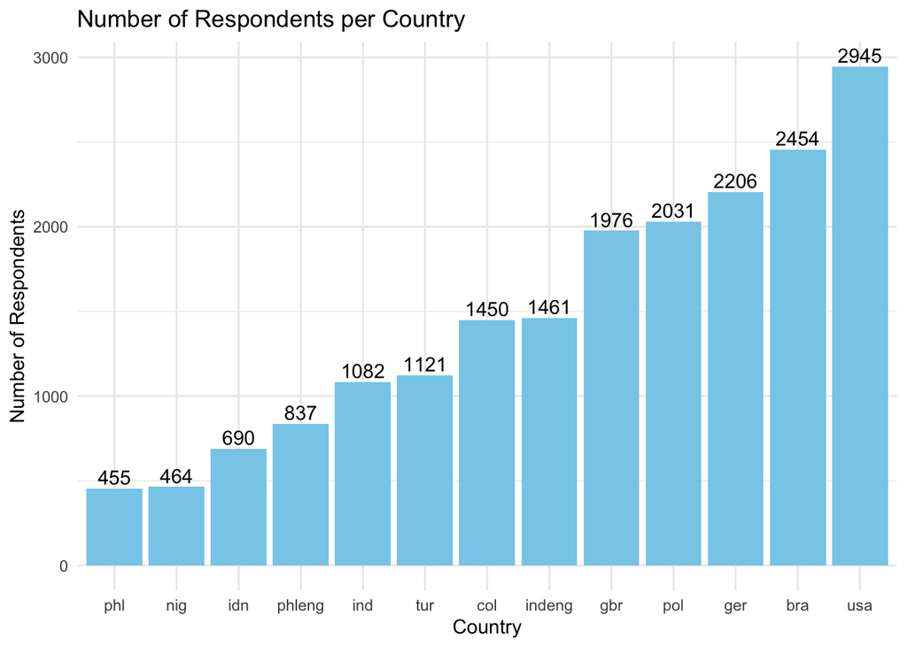

For potential subgroup analysis on countries it should be taken into account that respondent numbers differ from 455 (phl) to 2945 (USA).

## 2.2 Sample Balance Check

According to the pre-analysis plan of the main study, the respondents should be balanced across age (18-40 and 41-65+), sex (male, female), and education (below college, at least college education).

### 2.2.1 Age

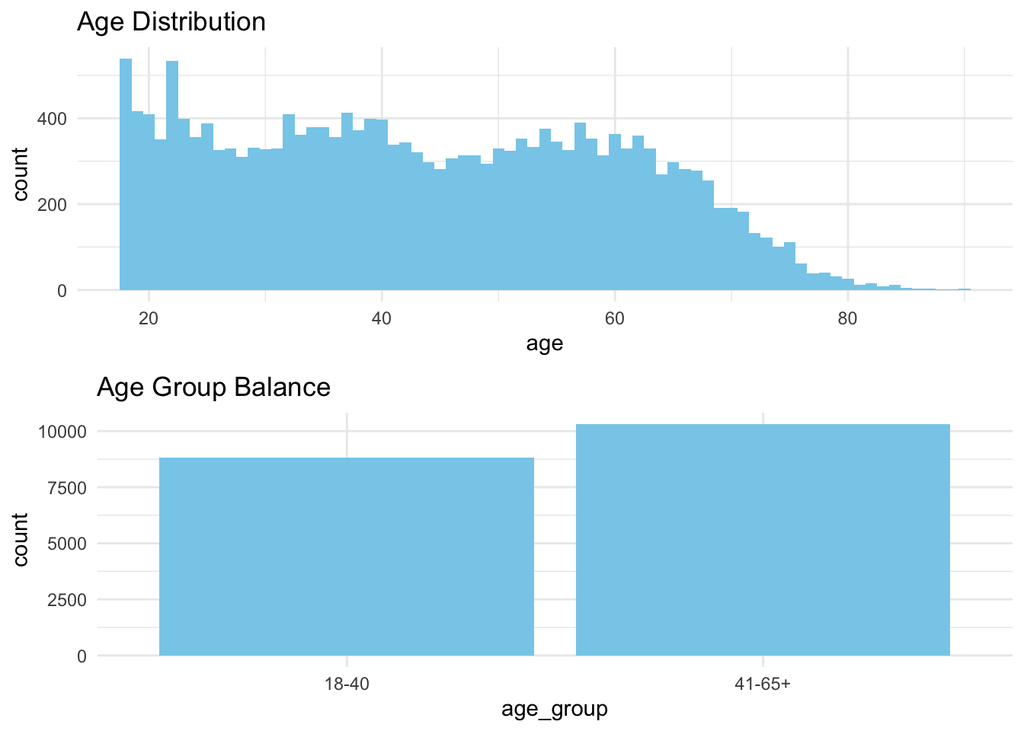

The age groups are relatively balanced. In case of excluding respondents below or equal 25, I check how many observations would not be taken into account for the analysis:

```
## # A tibble: 3 × 3
## # Groups:   age <= 25, age > 25 [3]
##   `age <= 25` `age > 25`     n
##   <lgl>       <lgl>      <int>
## 1 FALSE       TRUE       15734
## 2 TRUE        FALSE       3391
## 3 NA          NA            47
```

I would lose 3,391 observations by excluding people younger than 25 or 25 years old.

### 2.2.2 Gender

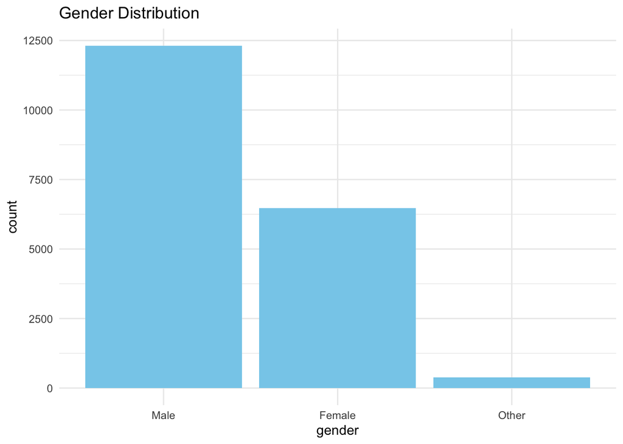

Since there are many more male respondents, it should be taken into account that the sample is not balanced across gender.

### 2.2.3 Education

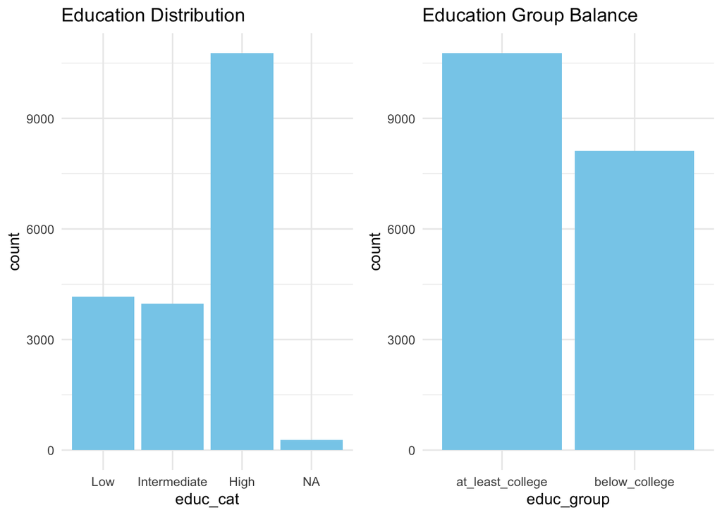

# 3 Overall Missingness

Before visualizing overall missingness in the data, we drop those variables that have already been summarized in an additional categorical variable (e.g. ethnicity) or that are country specific and will be looked at separately (e.g. partyid_), to avoid distortion of the picture.

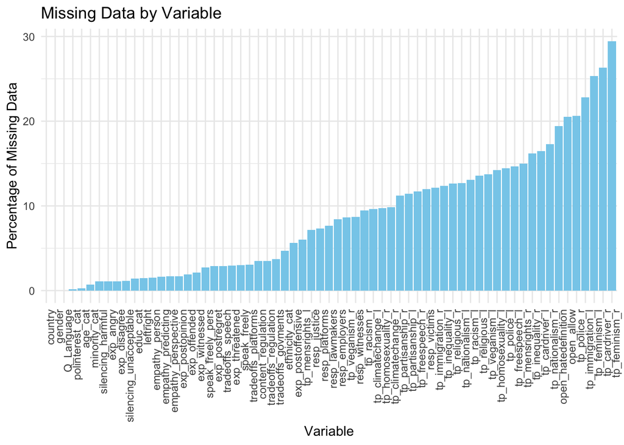

```r
# drop variable groups that are already transformed into categorical variables or are country-specific
data_selected_2 <- data_clean %>%
  dplyr::select(c("gender", starts_with("tp_"), "speak_freely", "leftright", "speak_freely_pers",
                  starts_with("silencing_"), starts_with("empathy"), starts_with("exp_"),
                  starts_with("tradeoffs_"),starts_with("resp_")), "content_regulation", "open_hatedefinition",
                "open_allow", "Q_Language", "country", "age_cat", "educ_cat", "ethnicity_cat", "minority_cat",
                "polinterest_cat")

# Calculate missing values
missing_values <- sapply(data_selected_2, function(x) sum(is.na(x)))
missing_percentage <- sapply(data_selected_2, function(x) sum(is.na(x)) / length(x) * 100)
missing_data <- data.frame(Variable = names(data_selected_2), MissingValues = missing_values, MissingPercentage = missing_percentage)

# Order data by missing percentage
missing_data <- missing_data %>% arrange(desc(MissingPercentage))

# Create a bar plot
ggplot(missing_data, aes(x = reorder(Variable, MissingPercentage), y = MissingPercentage)) +
  geom_bar(stat = 'identity', fill = 'skyblue') +
  theme_minimal() +
  theme(axis.text.x = element_text(angle = 90, hjust = 1)) +
  labs(x = 'Variable', y = 'Percentage of Missing Data', title = 'Missing Data by Variable')
```

```r
# Print the table of missing data
print(missing_data)
```

```
##                                      Variable MissingValues MissingPercentage
## tp_feminism_r                   tp_feminism_r          5646        29.4491967
## tp_cardriver_r                 tp_cardriver_r          5050        26.3404966
## tp_feminism_l                   tp_feminism_l          4855        25.3233883
## tp_immigration_l             tp_immigration_l          4372        22.8040893
## tp_police_r                       tp_police_r          3957        20.6394742
## open_allow                         open_allow          3932        20.5090757
## open_hatedefinition       open_hatedefinition          3725        19.4293762
## tp_nationalism_r             tp_nationalism_r          3319        17.3117046
## tp_cardriver_l                 tp_cardriver_l          3154        16.4510745
## tp_inequality_r               tp_inequality_r          3101        16.1746297
## tp_mensrights_r               tp_mensrights_r          2869        14.9645316
## tp_freespeech_l               tp_freespeech_l          2811        14.6620071
## tp_police_l                       tp_police_l          2768        14.4377217
## tp_homosexuality_l         tp_homosexuality_l          2725        14.2134363
## tp_veganism_l                   tp_veganism_l          2633        13.7335698
## tp_religious_l                 tp_religious_l          2600        13.5614438
## tp_racism_l                       tp_racism_l          2510        13.0920092
## tp_nationalism_l             tp_nationalism_l          2429        12.6695180
## tp_religious_r                 tp_religious_r          2427        12.6590862
## tp_inequality_l               tp_inequality_l          2366        12.3409138
## tp_immigration_r             tp_immigration_r          2328        12.1427081
## resp_victims                     resp_victims          2293        11.9601502
## tp_freespeech_r               tp_freespeech_r          2240        11.6837054
## tp_partisanship_l           tp_partisanship_l          2191        11.4281243
## tp_partisanship_r           tp_partisanship_r          2152        11.2247027
## tp_climatechange_r         tp_climatechange_r          1888         9.8476946
## tp_homosexuality_r         tp_homosexuality_r          1870         9.7538076
## tp_climatechange_l         tp_climatechange_l          1843         9.6129773
## tp_racism_r                       tp_racism_r          1812         9.4512831
## resp_witnesses                 resp_witnesses          1672         8.7210515
## tp_veganism_r                   tp_veganism_r          1659         8.6532443
## resp_employers                 resp_employers          1610         8.3976633
## resp_lawmakers                 resp_lawmakers          1472         7.6778636
## resp_platforms                 resp_platforms          1404         7.3231796
## resp_justice                     resp_justice          1370         7.1458377
## tp_mensrights_l               tp_mensrights_l          1151         6.0035468
## exp_postoffensive           exp_postoffensive          1075         5.6071354
## ethnicity_cat                   ethnicity_cat           898         4.6839140
## tradeoffs_govments         tradeoffs_govments           711         3.7085333
```

[output cut: 11 more lines]

```
## empathy_perspective       empathy_perspective           327         1.7056124
## empathy_predicting         empathy_predicting           318         1.6586689
## empathy_person                 empathy_person           295         1.5387023
## leftright                           leftright           285         1.4865429
## educ_cat                             educ_cat           271         1.4135197
## silencing_unacceptable silencing_unacceptable           220         1.1475068
## exp_disagree                     exp_disagree           212         1.1057793
## exp_angry                           exp_angry           211         1.1005633
## silencing_harmful           silencing_harmful           206         1.0744836
## minority_cat                     minority_cat           130         0.6780722
## age_cat                               age_cat            47         0.2451492
## polinterest_cat               polinterest_cat            26         0.1356144
## gender                                 gender             0         0.0000000
## Q_Language                         Q_Language             0         0.0000000
## country                               country             0         0.0000000
```

**First Conclusions**

- Most NA’s are in sub questions of political preferences and open text items
- We have full data availability for gender, language, and country.
- Less than one per cent is missing in minority, age, and political interest

**Educational Attainment (educ_cat)**: only 1.4 per cent missing -> observations without information can just be dropped

**Hate Definition (open_hatedefinition)**: 19.4 per cent missing -> further analysis of characteristics of those missing should be done

# 4 Variables of interest

## 4.1 Educational Attainment

### 4.1.1 Distribution across different Countries

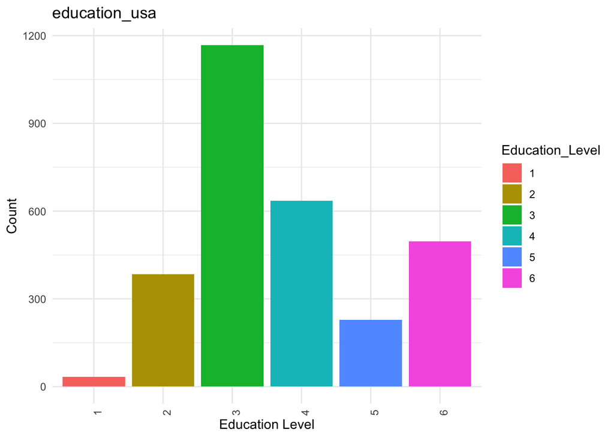

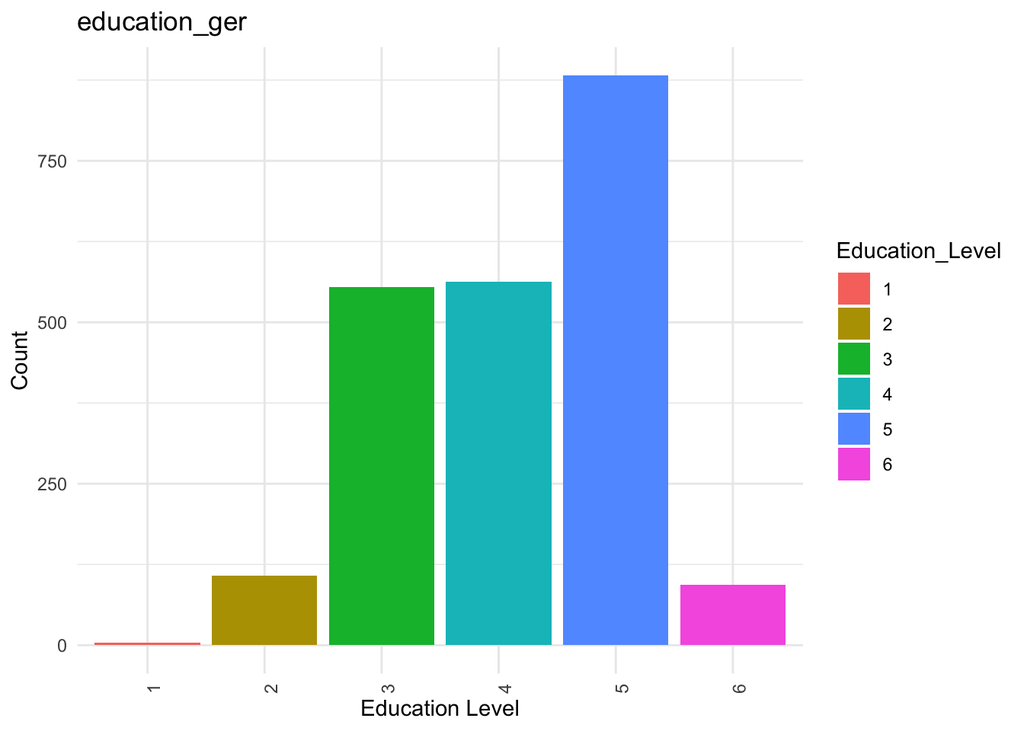

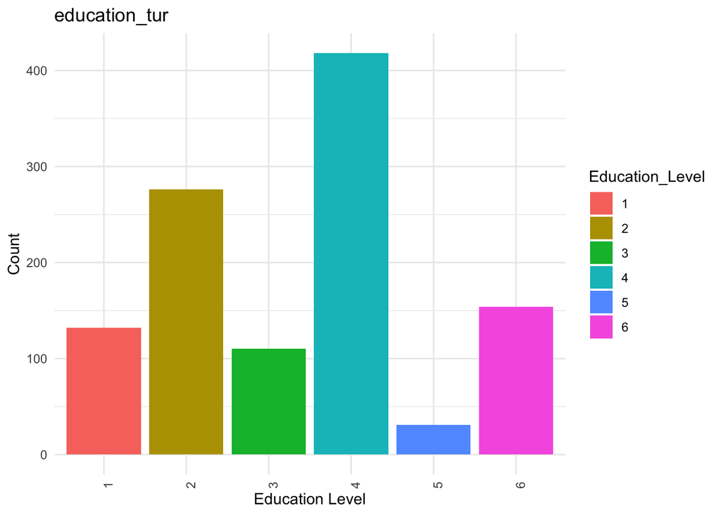

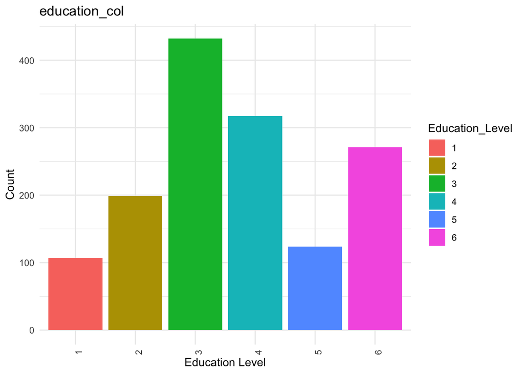

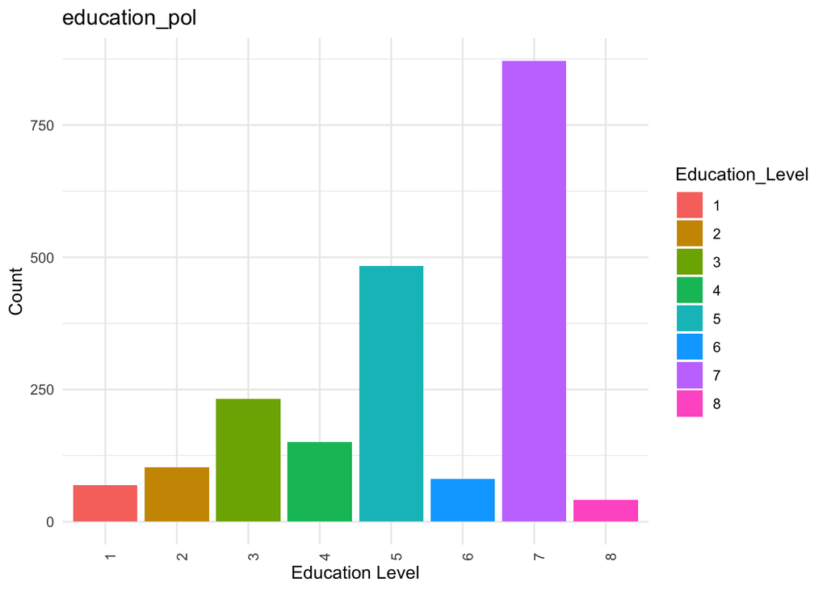

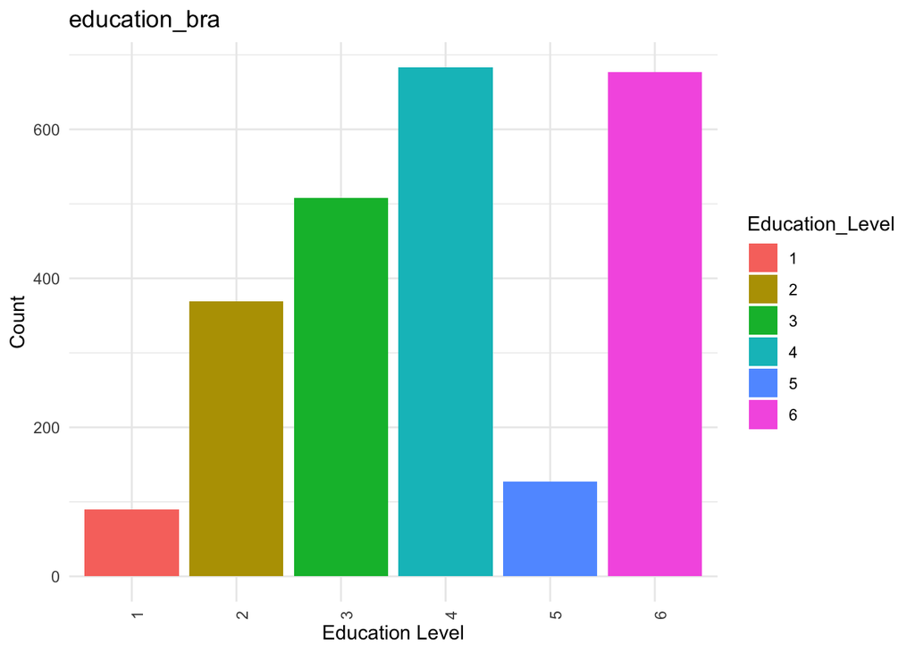

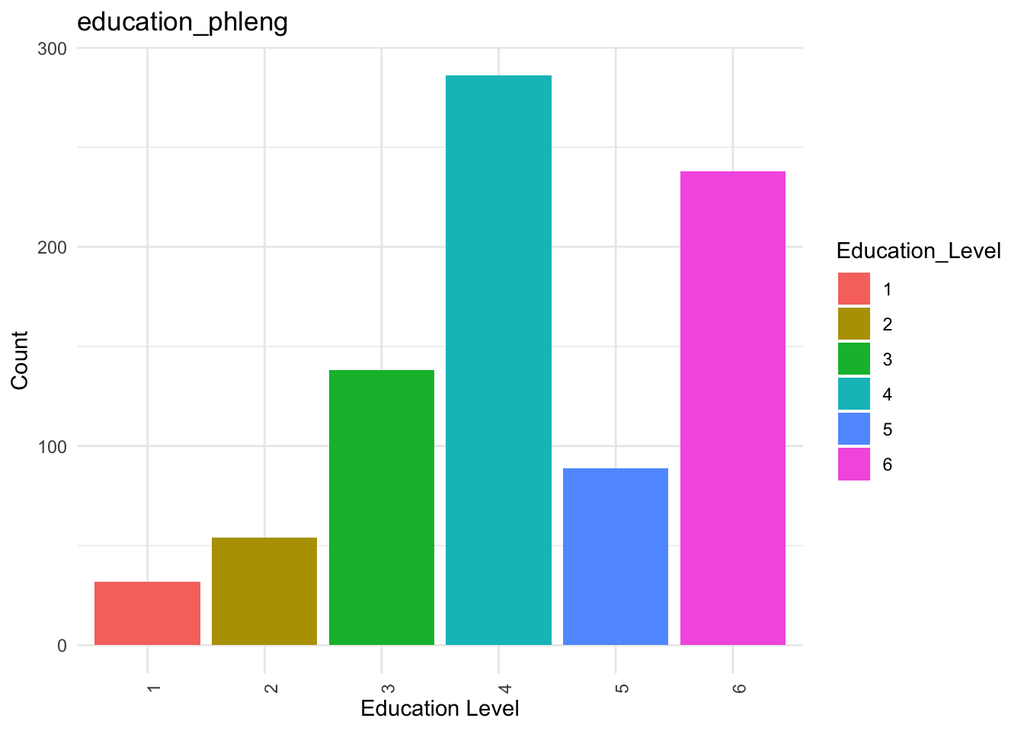

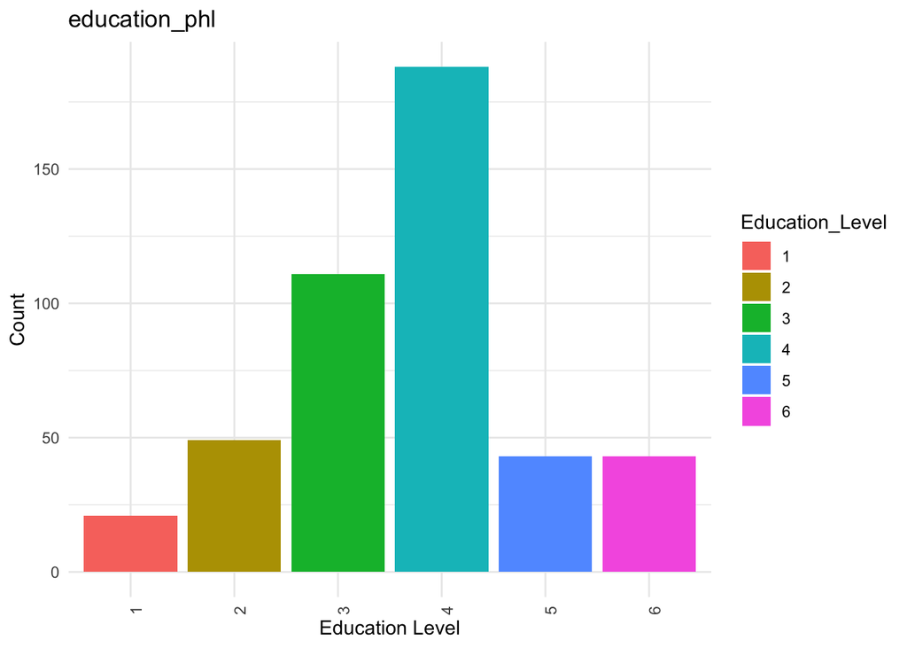

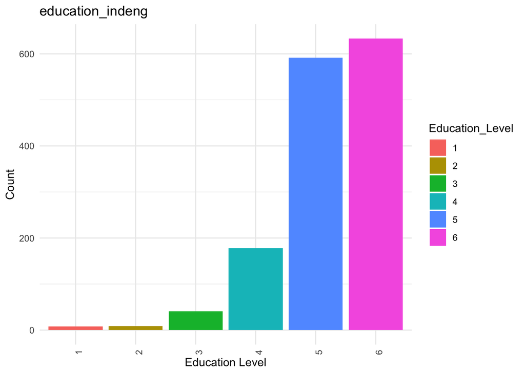

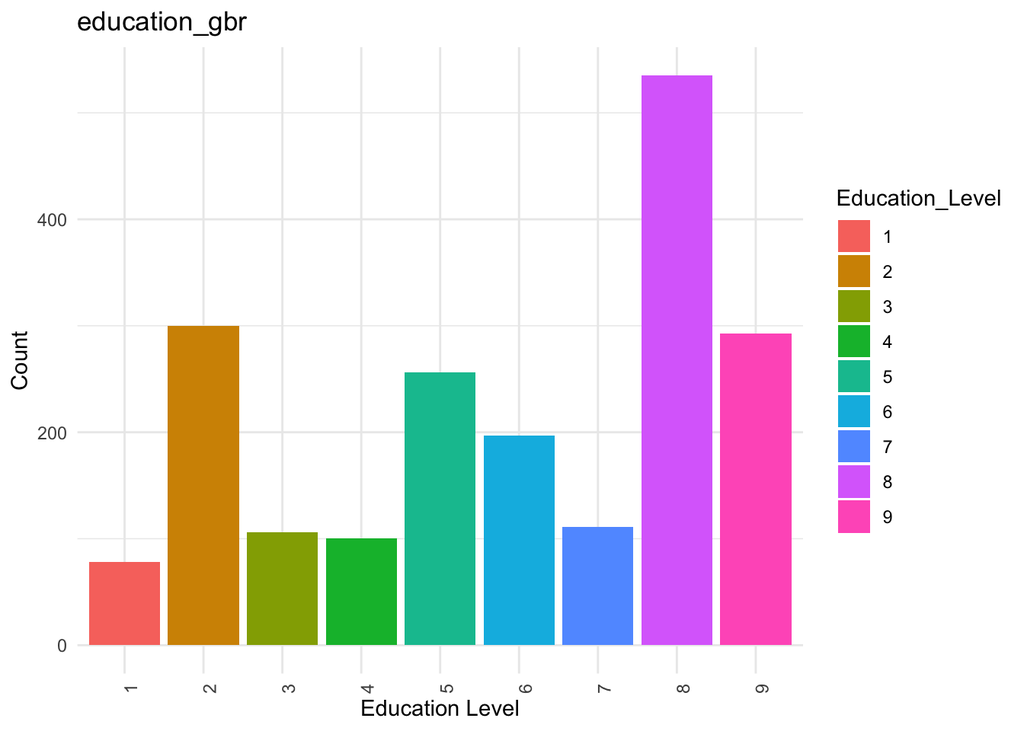

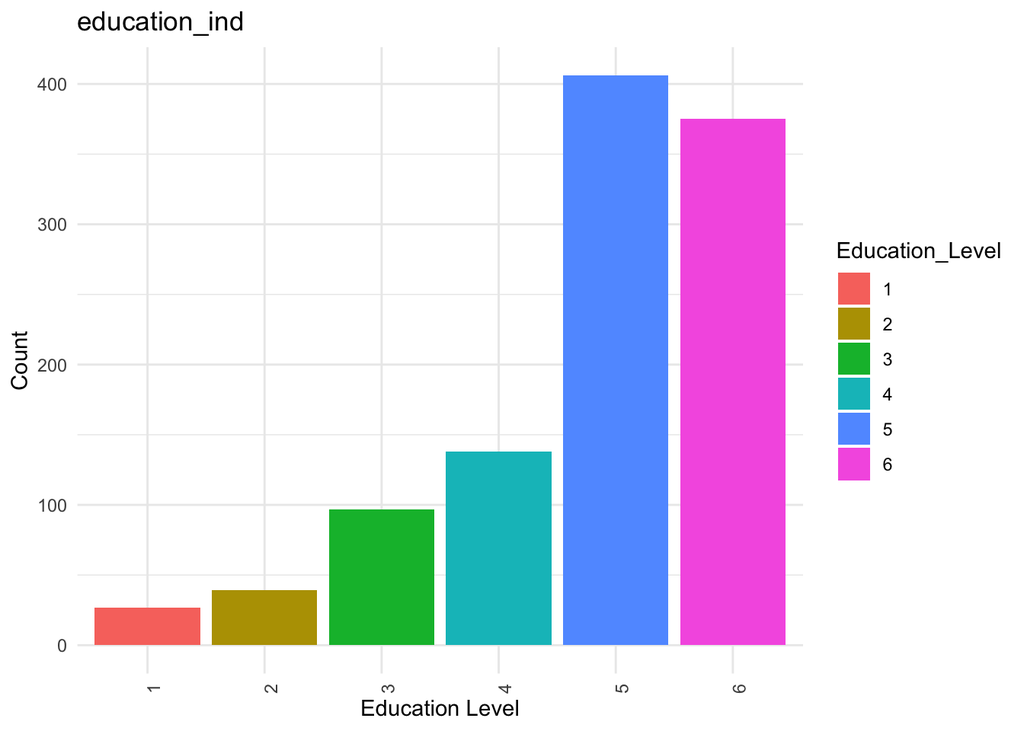

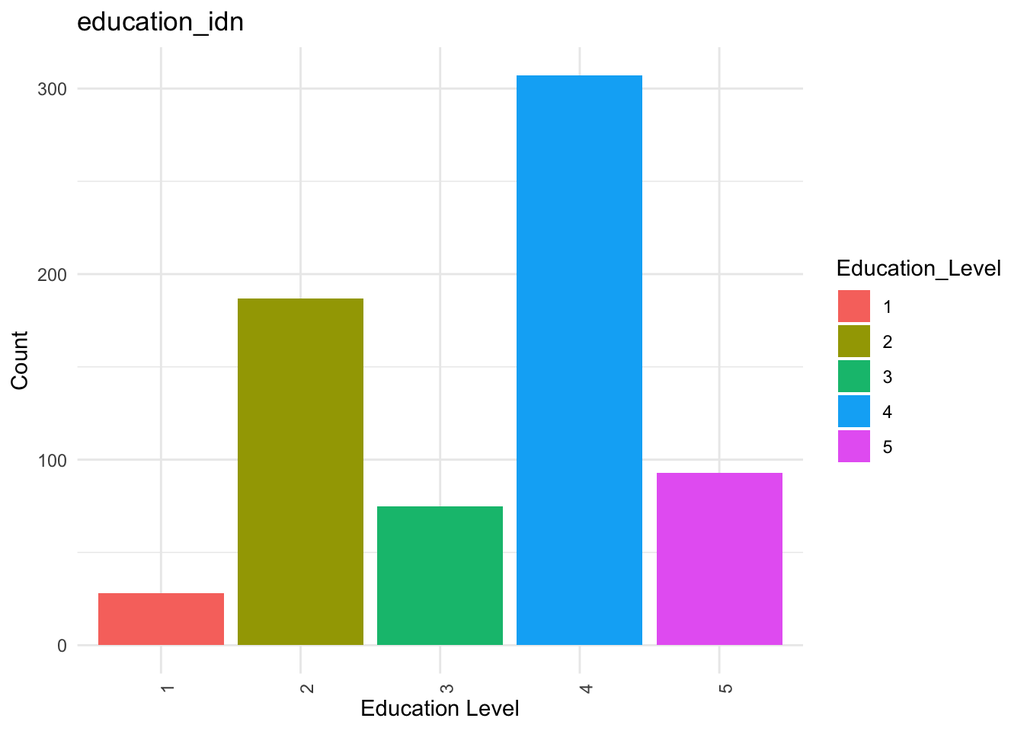

[1 more figures not shown]

### 4.1.2 Distribution across Demographic Groups

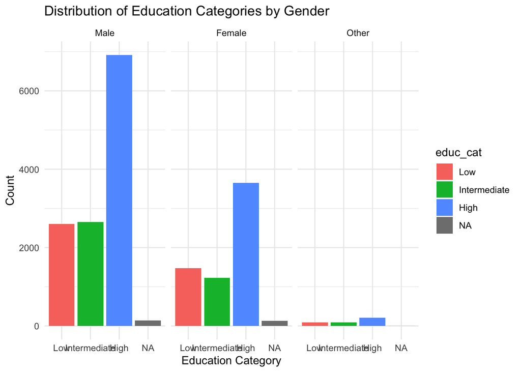

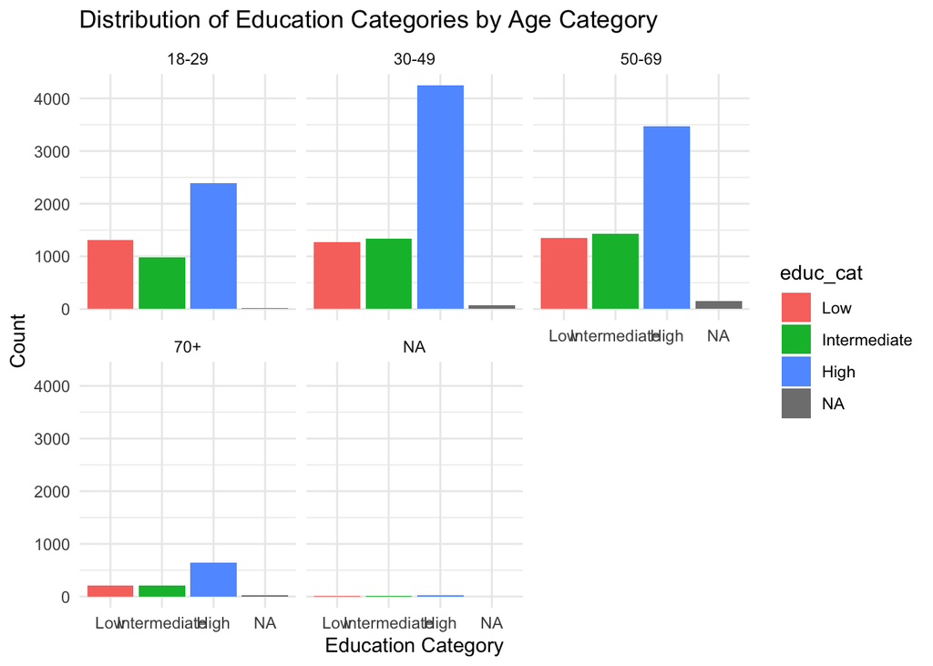

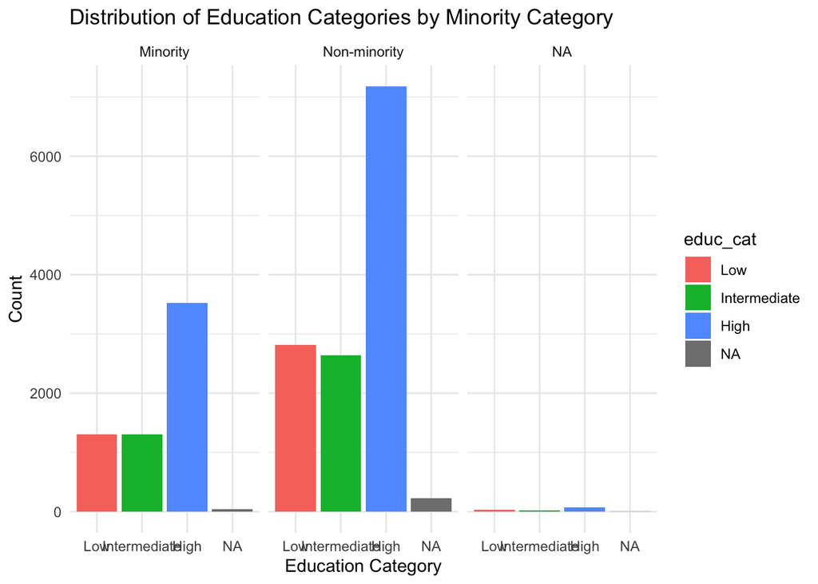

## 4.2 Open-Text Items

### 4.2.1 Definition of Hate Speech

Look at some examples that I can read (German and English):

```
## # A tibble: 1 × 1
##       n
##   <int>
## 1  6452
```

Roughly a third of the observations are in English or German language.

```
## # A tibble: 20 × 1
##    open_hatedefinition
##    <chr>
##  1 "Anyone can call anything hate speech. Even this first sentence someone coul…
##  2 "Persönliche Beleidigung oder Androhung von Gewalt."
##  3 "Seems that in modern times, anything that someone is offended by is all of …
##  4 "Aufruf zur Gewalt oder eindeutige beabsichtigte Diskriminierung/Beleidigung…
##  5 "Some persons hate, and are either led into that or develop it on their own …
##  6 "Hate speech refers to offensive discourse targeting a group or an individua…
##  7 "Speech that harasses, threatens, or encourages violence against a person or…
##  8 "Direkte persönliche Beleidigung."
##  9 "Words that others would find offensive toward their ethnic, social or commu…
## 10 "Speech that poses a significant threat to persons of a specific race, relig…
## 11 "Hate speech is a term that has such loosely defined parameters that it is b…
## 12 "Hate speech is speech that encourages violence against various groups of pe…
## 13 "Saying one race is superior to another or calling for the genocide of any t…
## 14 "Hate Speech is when you try to strip a person of their humanity.  When you …
## 15 "Ist mir kein Begriff."
## 16 "Gewaltaufruf...\n...aber da links-grün heute definiert, was Hassrede ist, w…
## 17 "Inhalte, die gezielt auf Personen und Gruppen von Menschen ausgerichtet sin…
## 18 "Hate Speech is direct attack on a persons race, religion, occupation, etc. …
## 19 "Comments that openly encourage violence or mistreatment of others due to ra…
## 20 "Hassrede ist, wenn jemand gezielt eine Person persönlich angreift und belei…
```

**Text Length**

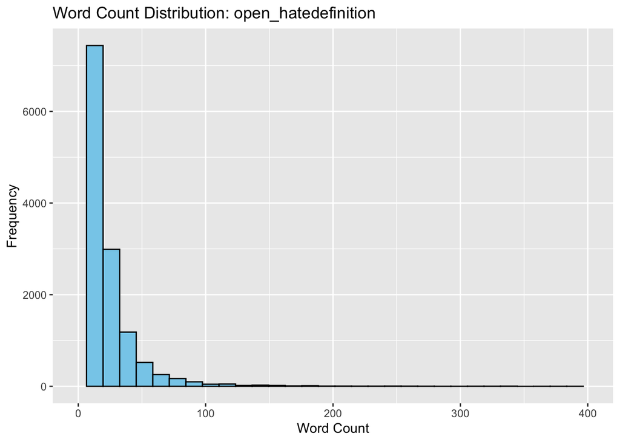

Almost all answers have a length below 100.

**Missingness**

Seen that there is high missingness (19.4%) in my outcome variable, I want to find out more about people who did not specify their own definition of hate speech.

```
##          educ_cat       gender      age_cat           minority_cat
##  Low         : 971   Male  :2345   18-29:1176   Minority    :1073
##  Intermediate: 699   Female:1321   30-49:1293   Non-minority:2617
##  High        :2020   Other :  59   50-69:1052   NA's        :  35
##  NA's        :  35                 70+  : 188
##                                    NA's :  16
```

### 4.2.2 What should not be allowed to say on social media?

Look at 20 examples:

```
## # A tibble: 20 × 1
##    open_allow
##    <chr>
##  1 "Conditioning of children or organization of human trafficking and violence."
##  2 "Man darf alles sagen, solange es keinen Menschen beleidigend, rassistisch o…
##  3 "People need to just stop being offended by everything they see. People are …
##  4 "Abusive, bigoted or threatening comments against any race, religion, nation…
##  5 "Aufrufe zur Gewalt und vergleichbare Aussagen, welche auch eine tatsächlich…
##  6 "In my experience, no past attempts to completely control the behavior of ot…
##  7 "If this would happen, we cannot merely express our opinions and tell what i…
##  8 "You should be allowed to say anything except hate speech. Misinformation sh…
##  9 "Strafbare Äußerungen"
## 10 "Man sollte alles sagen können."
## 11 "Cursing of others, labeling others as \"trash\" or other undesirable THINGS…
## 12 "Direct, actionable threats to people or classes of people.  Talk like “ all…
## 13 "Direct threats such as \"I know where you live and am going to kill you.\" …
## 14 "Anything that incites violence. You should be able to express your views ev…
## 15 "Actual death threats, calls to kill or violently harm a particular person."
## 16 "I totally believe in free speech, but under certain conditions.  Same condi…
## 17 "Nichts."
## 18 "Schlimme Dinge dürfen erst zensiert werden, wenn eine ordentliche Justiz, d…
## 19 "Angriffe und Aufforderungen zu Straftaten."
## 20 "Profanity, cursing should be prohibited.  Other opinions can be brought up,"
```

**Text length**

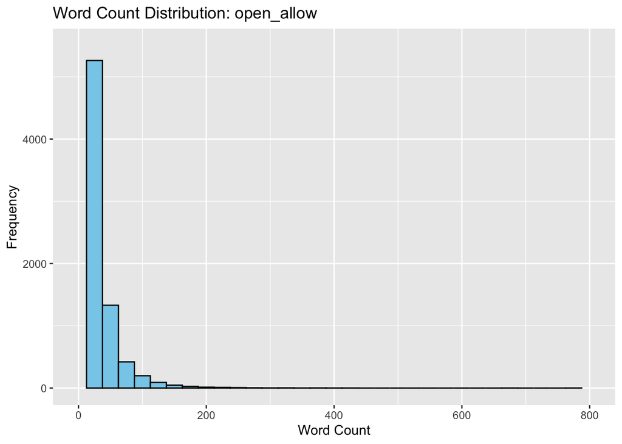

Almost all answers have a length below 200.

**Missingness**

Seen that there is high missingness (20.5%) in my second outcome variable, I want to find out more about people who did not specify their speech prohibition preferences.

```
##          educ_cat       gender      age_cat           minority_cat
##  Low         :1020   Male  :2507   18-29:1273   Minority    :1152
##  Intermediate: 733   Female:1356   30-49:1372   Non-minority:2746
##  High        :2144   Other :  69   50-69:1082   NA's        :  34
##  NA's        :  35                 70+  : 188
##                                    NA's :  17
```

### 4.2.3 Comparison

```
##              Variable Min Max     Mean       SD
## 1 open_hatedefinition   1 392 16.82412 22.01840
## 2          open_allow   1 763 16.44758 25.55582
```

## 4.3 Other variables of interest

### 4.3.1 Political interest

[polinterest_cat]

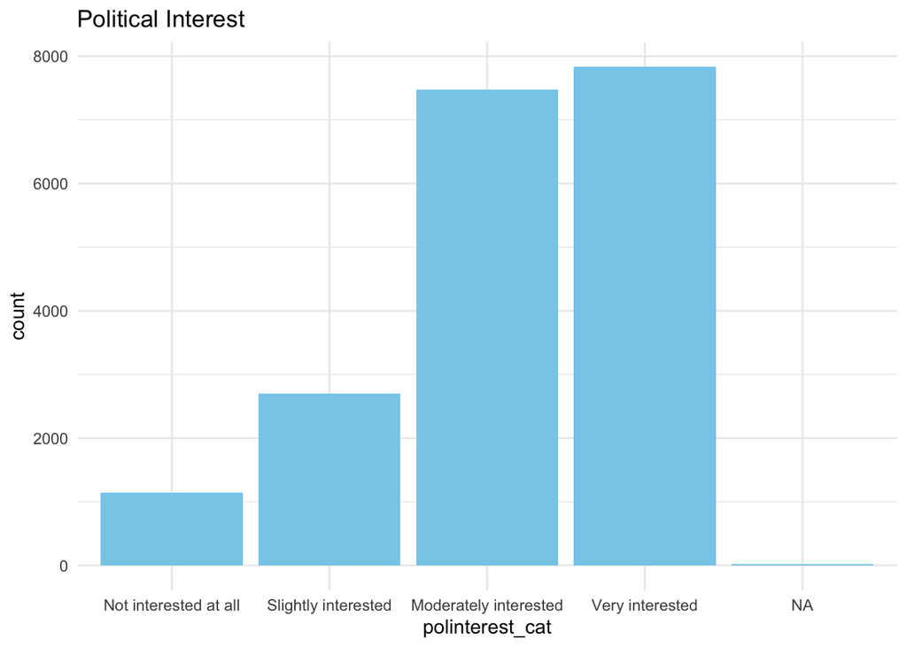

### 4.3.2 Left-right Scale

[leftright]

```
## # A tibble: 1 × 4
##     min   max  mean    sd
##   <dbl> <dbl> <dbl> <dbl>
## 1     1    11  6.03  2.68
```

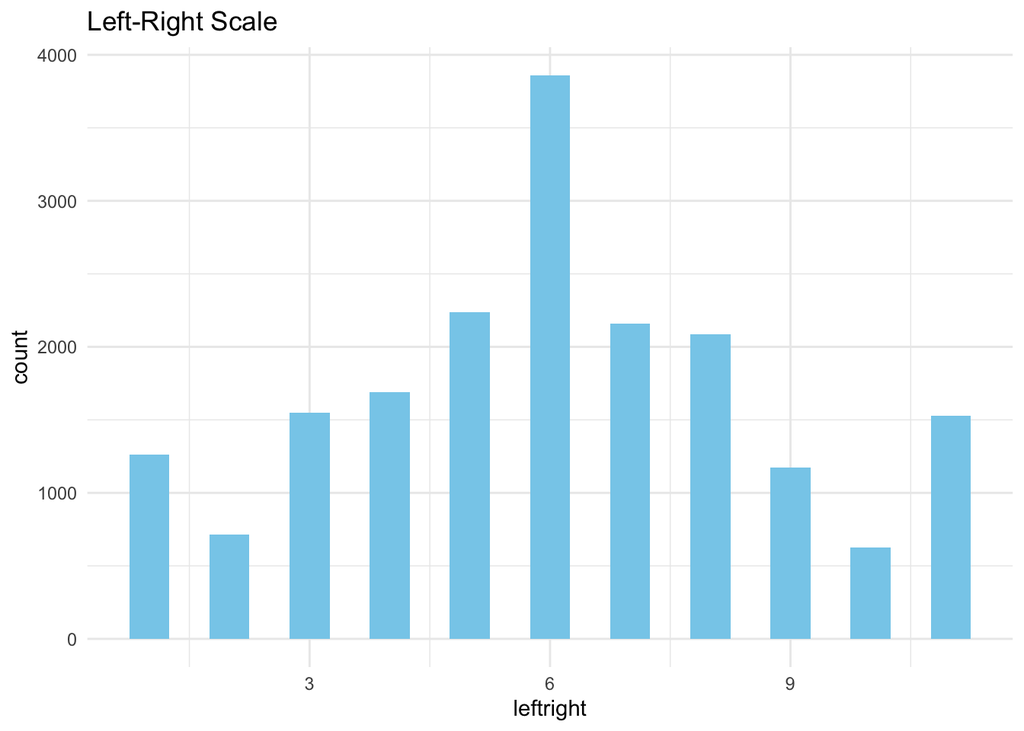

### 4.3.3 Empathy

[empathy_person, empathy_predicting, empathy_perspective]

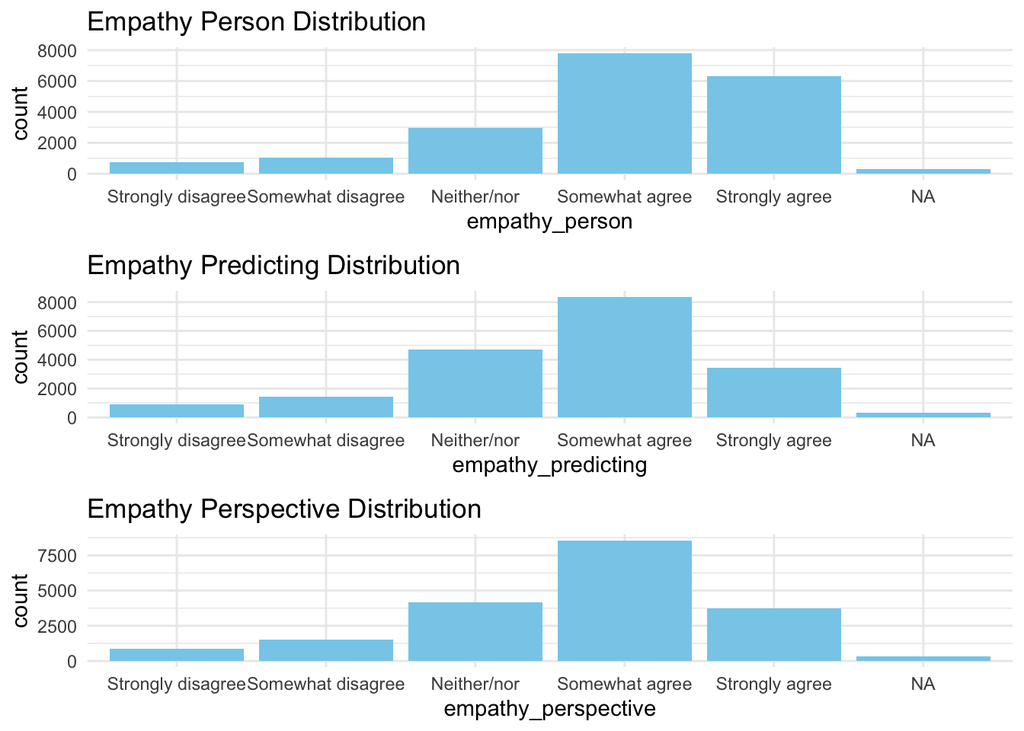

Respondents rather see themselves as being very empathetic - this is probably biased. Never the less, there is a certain distribution.

### 4.3.4 Experience with Hate and Offensive Speech

[exp_offended, exp_threatened, exp_witnessed, exp_disagree, exp_angry]

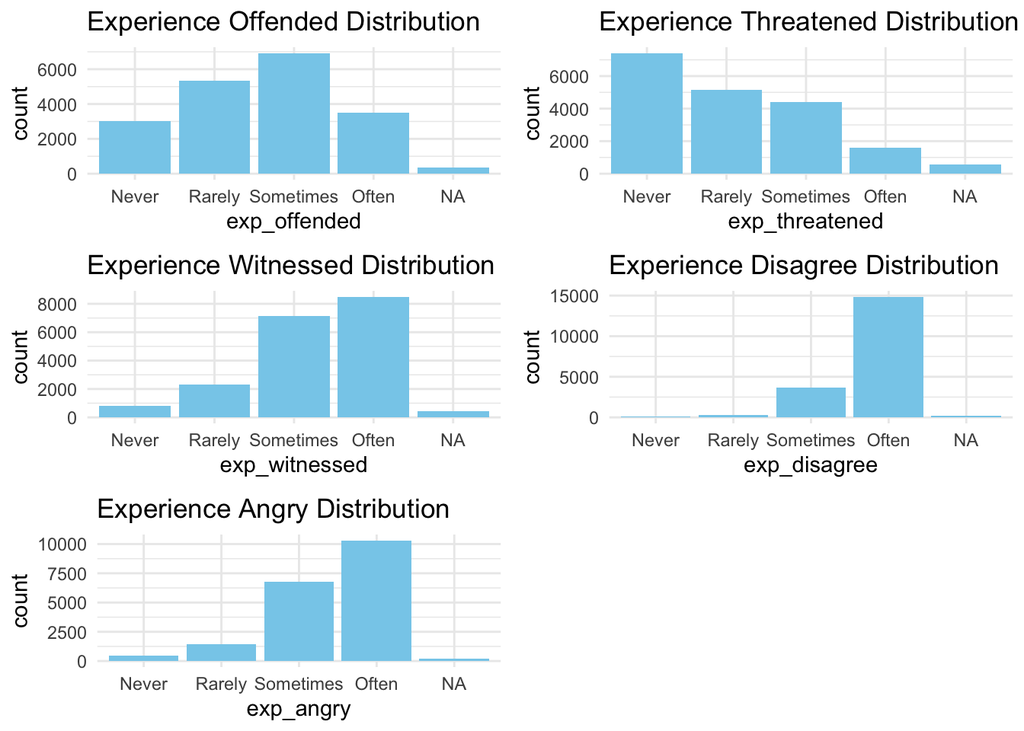

### 4.3.5 Online Hostile Engagement

[exp_postregret, exp_postoffensive, exp_postopinion]

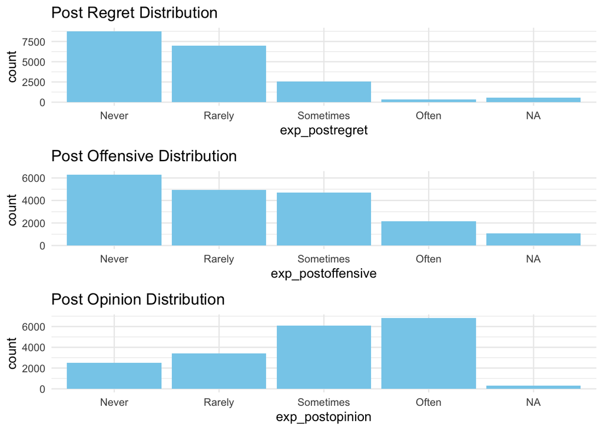